# Module 6: Writing Quantum Circuits

# Summary

- Representing a quantum circuit
- Programming your first quantum circuit
- Making sense of the output/result of a quantum circuit
- Examples of single qubit circuits

# Representing Quantum Circuits

- *Quantum* circuits are read from left to right.
- A *qubit* in a *quantum* circuit is represented by a wire.
  - convention: qubits are always initialized in the state $\left| 0 \right \rangle$.
- A *single qubit gate* is represented by a square on the wire, with the name of the gate inside.

[figure not shown]

- A *measurement* is represented as follows:

[figure not shown]

- Example:

[figure not shown]

### Programming Quantum Circuits

- *qiskit*: A Python library developed by IBM which lets us build and run quantum circuits.
- We can run the circuits we write on IBM's actual hardware, or we can *simulate* quantum circuits of small enough size on classical computers.

### Your First Quantum Program

- Start from a qubit in the state $\left| 0 \right \rangle$.
- Create an equal superposition of $\left| 0 \right \rangle$ and $\left| 1 \right \rangle$ (by applying a Hadamard gate).
- Measure the qubit.

```python
from qiskit import QuantumCircuit #import qiskit
```

```python
circ = QuantumCircuit(1,1)  #create QuantumCircuit object
circ.h(0)  #add Hadamard gate to circuit
circ.measure(0,0); #add a measurement to the circuit
```

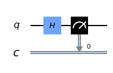

```python
circ.draw(output='mpl') #draw circuit
```

### Execute the circuit

```python
from qiskit import Aer, execute # Import Aer and execute
backend_sim = Aer.get_backend('qasm_simulator') #create backend object
```

```python
sim = execute(circ, backend_sim, shots=1024) #run the simulation
```

```python
sim_result = sim.result() #get result object
counts = sim_result.get_counts(circ) #obtain the counts from the result object
print(counts)
```

```
{'1': 498, '0': 526}
```

## Analyzing your first quantum program

- Upon applying $H$ to $\left| 0 \right\rangle$, the state of the qubit is

$$\begin{align}\left| \psi \right\rangle= \tfrac{1}{\sqrt{2}} \left| 0 \right\rangle+\tfrac{1}{\sqrt{2}} \left| 1 \right\rangle \end{align}$$

- We then performed a measurement. By Born's rule, the measurement yields outcomes $0$ and $1$ with probabilities $1/2$ and $1/2$ respectively.
- We executed the experiment many times (`'shots'=1024`), and indeed we observed approximately a 50-50 split between outcomes 0 and 1.

### Visualizing the results

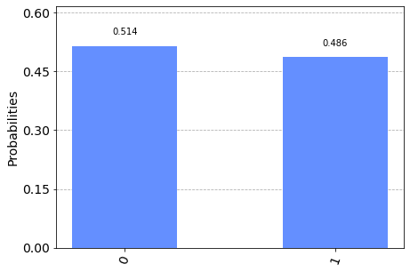

```python
from qiskit.visualization import plot_histogram
plot_histogram(counts)
```

### Another Quantum Program

- Start with the $\left| 0 \right\rangle$ state
- Apply an $X$ gate.
- Measure the qubit.

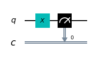

```python
from qiskit import QuantumCircuit
circ = QuantumCircuit(1,1)
circ.x(0)
circ.measure(0,0)
circ.draw(output='mpl')
```

```
{'1': 1024}
```

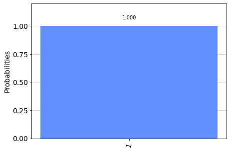

```python
from qiskit import Aer, execute
backend_sim = Aer.get_backend('qasm_simulator')
sim = execute(circ, backend_sim, shots=1024)
sim_result = sim.result()
counts = sim_result.get_counts(circ)
print(counts)

plot_histogram(counts)
```

**Exercise.** Write and run a program that starts with the state $\left| 0 \right\rangle$, applies the following sequence of gates $X$, $H$, $X$, $H$, and then measures. Estimate the probability of obtaining outcome 0.

```python
from qiskit import QuantumCircuit, Aer, execute
circ=QuantumCircuit(1,1)

#your code here
circ.x(0)
circ.h(0)
circ.x(0)
circ.h(0)

#execute the circuit
backend_sim = Aer.get_backend('qasm_simulator')
sim = execute(circ, backend_sim, shots=1024)
sim_result = sim.result()
counts = sim_result.get_counts(circ)
print(counts)
```

[output not shown]

# Detecting Relative Phase

- Hadamard gate $H$:

$$\begin{array}{1} H\left|0\right\rangle= \frac{1}{\sqrt{2}}\big(\left|0\right\rangle+\left|1\right\rangle\big) \\ H\left|1\right\rangle=\frac{1}{\sqrt{2}}\big(\left|0\right\rangle-\left|1\right\rangle\big)\end{array}$$

- Recall:

$$\begin{array}{1} H \frac{1}{\sqrt{2}}\big(\left|0\right\rangle+\left|1\right\rangle\big) = \left|0\right\rangle \\ H \frac{1}{\sqrt{2}}\big(\left|0\right\rangle-\left|1\right\rangle\big) = \left|1\right\rangle\end{array}$$

> How do we distinguish between these two states?
- Prepare the state $H \left| 0\right\rangle$.

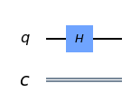

```python
from qiskit import QuantumCircuit
circ_0 = QuantumCircuit(1,1)
# Apply the Hadamard gate.
circ_0.h(0)
circ_0.draw(output='mpl')
```

- Prepare $H \left| 1\right\rangle$.

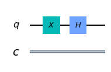

```python
from qiskit import QuantumCircuit
circ_1 = QuantumCircuit(1,1)
# Flip the initial 0 state to a 1 by applying an X gate
circ_1.x(0)
# Apply the Hadamard gate.
circ_1.h(0)
circ_1.draw(output='mpl')
```

```python
circ_0.h(0)
circ_0.measure(0,0)

circ_1.h(0)
circ_1.measure(0,0)
```

```
<qiskit.circuit.instructionset.InstructionSet at 0x7fcfc62ae750>
```

```
{'0': 1024}
```

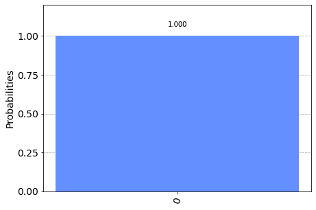

```python
from qiskit import Aer, execute
backend_sim = Aer.get_backend('qasm_simulator')
sim = execute(circ_0, backend_sim, shots=1024)
sim_result = sim.result()
counts = sim_result.get_counts(circ_0)
print(counts)

plot_histogram(counts)
```

```
{'1': 1024}
```

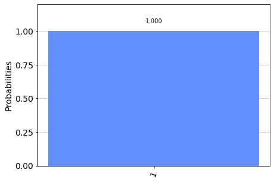

```python
from qiskit import Aer, execute
backend_sim = Aer.get_backend('qasm_simulator')
sim = execute(circ_1, backend_sim, shots=1024)
sim_result = sim.result()
counts = sim_result.get_counts(circ_1)
print(counts)

plot_histogram(counts)
```

- The reason for what we observed is that:
  - $$ H \left(\frac{1}{\sqrt{2}} \left|0\right\rangle+ \frac{1}{\sqrt{2}}\left|1\right\rangle\right) = \left| 0\right\rangle$$
  - $$ H \left(\frac{1}{\sqrt{2}}\left|0\right\rangle - \frac{1}{\sqrt{2}}\left|1\right\rangle\right) = \left| 1\right\rangle$$